# Designing a model to suit the pathogen

SPARK short course, Indonesia, March 2023

Presenter: [Roslyn Hickson](https://research.jcu.edu.au/portfolio/roslyn.hickson/)

## Contributors

- With thanks to [Lisa White](http://www.tropmedres.ac/researchers/researcher/lisa-white), Nuffield Department of Medicine, Oxford University
- With thanks to [Wirichada Pan-Ngum](http://www.tropmedres.ac/wirichada-pan-ngum), Faculty of Tropical Medicine, Mahidol University
- Adapted and previously presented by [Emma McBryde](https://research.jcu.edu.au/portfolio/emma.mcbryde), Australian Institute of Tropical Health & Medicine, James Cook University
- Adapted by the presenter, [Roslyn Hickson](https://research.jcu.edu.au/portfolio/roslyn.hickson/), College of Public Health, Medical and Veterinary Sciences and Australian Institute of Tropical Health & Medicine, James Cook University, and CSIRO

# Practice in building a model

- Separate into groups of about 4 to 6 people
- With facilitation from a tutor or demonstrator, write a model for HIV, a disease with **lifelong carriage**. The aim is to capture the different disease states and flows between them, like in the last session. You can propose a model question for example: as an infectious disease epidemiologist, you notice a recent spike in HIV notifications. You want to project the number of cases of AIDS and the need for treatment over the next few years. Build a model that may help with the epidemiological projections.
  - Draw a diagram of a simple compartmental model and define the variables and parameters
  - Write down the ODEs
  - What would you do to improve/change this model for the next version? (No need to write the equations for this)
  - Nominate a rapporteur for each group for presentation in this session

You might find the following diagram helpful:

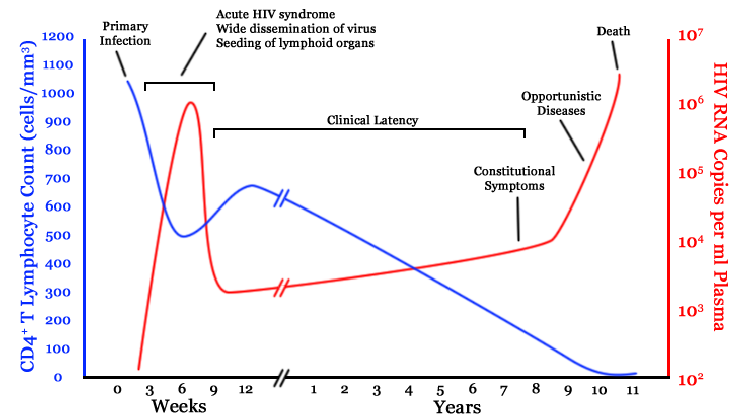

Upload your model diagram:

# Model presentation and discussion

- Each group in turn will present their model diagram and equations
- While the other group members will troubleshoot the presented model for structural and mathematical errors

## More practice

- Repeat this process for measles, a short-lived disease with **lifelong immunity**.

You might find the following diagram helpful:

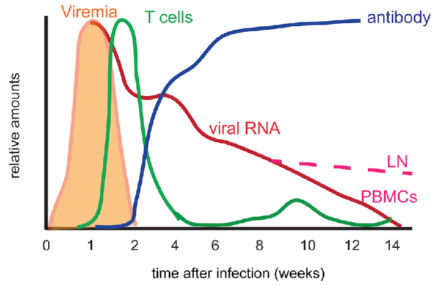

Upload your model diagram:

# Introduction to a Shiny App

- Download the SEIRS Shiny app and save it with your course files.
- Open it in RStudio and click **Run App**.

If this doesn’t work, you can try the online version: https://emmamcbryde.shinyapps.io/SEIR_model/. You should see something like this:

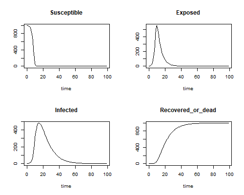

## Examine the graphs that plot S, E, I and R over time for the default parameters.

1. What kind of model is it?

Change the parameter for the basic reproduction number. What impact does this have on:

2. The duration of the epidemic?
3. The peak of infectious cases?
4. The final proportion of susceptibles?

Change the parameter for latency duration. What impact does this have on:

5. The duration of the epidemic?
6. The peak of infectious cases?
7. The final proportion of susceptibles?

Reduce the duration of immunity.

8. What type of model have we now created?
9. How does this impact on the number of susceptibles after a long time?
10. How does this impact on the number of infectious after a long time?
11. Why does the model have waves?

Examine the phase plane.

12. What is it showing?
13. Where is time on the phase plane?
14. What corresponds to the waves in the phase plane?

Continue to change the parameters to try and simulate the different model types such as those pictured below.

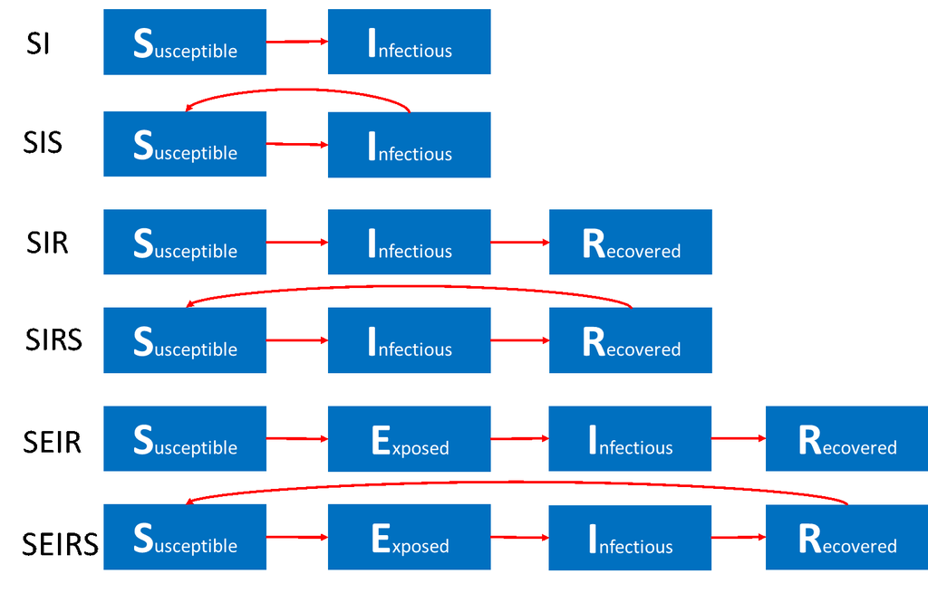